# Course Preliminaries, Data Structures

Day 1

Claire Kelling

Carleton College  
STAT 120 - Fall 2026

## Today’s Topics

- Introductions
- Overview of course structure, syllabus, and Moodle (brief)
- Course Introduction
- Structure of Data (and start intro to R!)

## 👋 I’m Claire

- From Cincinnati, Ohio
- Alum of Virginia Tech and Penn State
- Love discussing volleyball, outdoor activities (kayaking, hiking, etc.), data ethics, sociology, and much more!
- Come chat! 😊

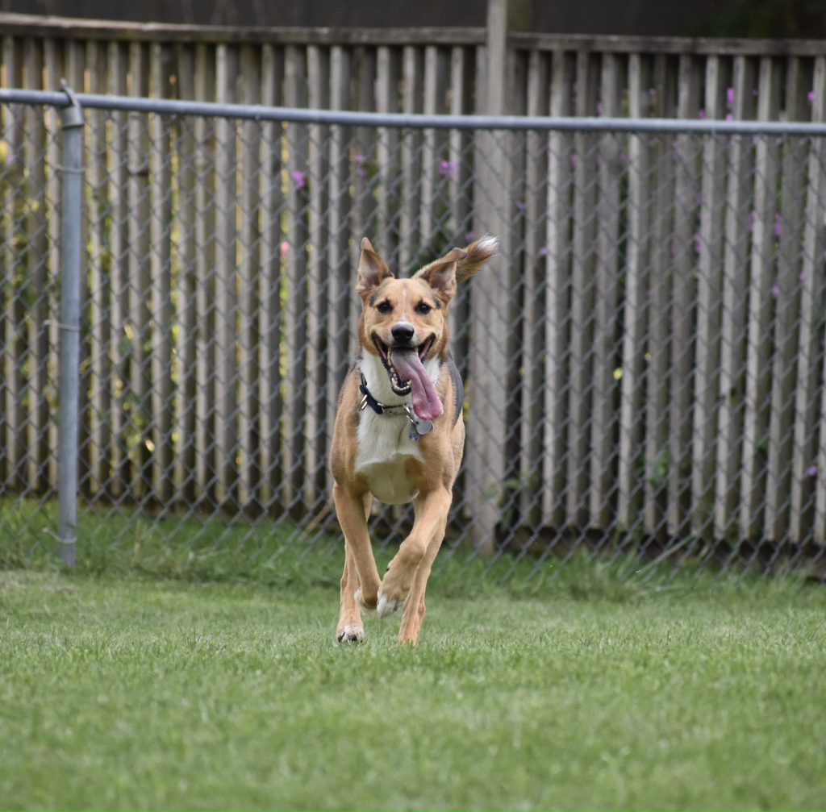

## Introductions

`05:00`

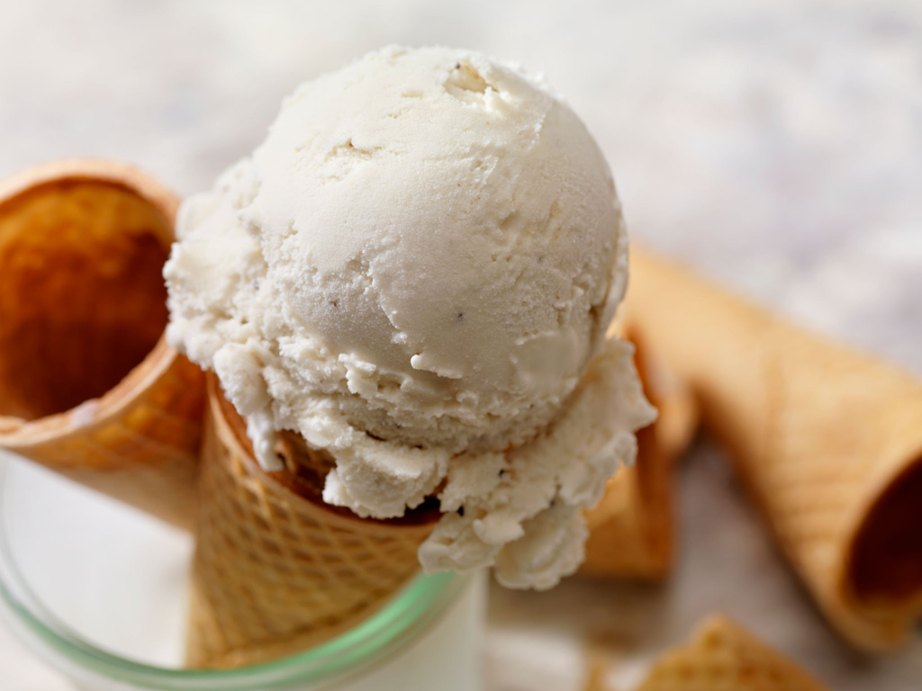

About You:

- Name and pronouns (if desired)
- Favorite dessert and one of your goals for the course

# Course Structure

## Course Structure

- Moodle
- Syllabus (quiz posted on Moodle)
- Calendly Appointments
- Anonymous Feedback
- Slack
- Learning in Community Quest
- In-class notes with write-in blanks

## Course Structure

Major course components:

- Participation (largely in-class group exercises, randomly assigned)
- Reading Checks
- Homework
- Quizzes (4)
- Statistical Writing: short report and final project
- Statistician of the Week (Extra Credit)

## AI Thoughts

**Policy**: Full policy in syllabus!

- I want to be a *guide and collaborator* in your learning, not the AI police!
- If you use it, I would suggest considering it as a tutor. I would encourage you never to use it for a first draft when you are trying to learn new content.
- Learning with others can be so much more fun and rewarding!
- No AI use is allowed on quizzes.
- You **must acknowledge any AI use on homeworks or reports** and your submissions must use class content.

**AI Agreement**: I want you to reflect about the potential effects of AI on learning and society (environmental, social, economic, etc.). Then you’ll connect this to your plans beyond what I’ve set in my policy. Please feel free to discuss your plans with me while you brainstorm! You’ll have 3 opportunities to revise this plan throughout the course.

## Things you’re excited about

- I hope this course can truly help me understand stats.
- I am exited about stepping out of my comfort zone! I haven’t taken math since High School so I’m ready to test myself.
- I’m excited to see how applicable statistics is to the real world!
- I am excited to learn R
- Stats are used in each subject I am looking at going into, so I am eager to get to know it better!

## Things you’re nervous about…

- Getting back into math after some time away
- I’m nervous about learning to code in R
- I’m nervous about using the different formulas
- I’m a little shy to speak in class.
- I am generally **not a math person**

## Take care of yourself!

Do your best to maintain a **healthy lifestyle** this semester by wearing a mask if you don’t feel well, eating vegetables every day, exercising, avoiding excessive drug and alcohol use, getting enough sleep, and taking some time to relax. **Your mental health is more important than your grade in this course.** There are many helpful resources available on campus and an important part of the college experience is learning how to ask for help. If you are experiencing mental health symptoms as a result of coursework, please speak with me so we can work towards a solution together.

# Course Introduction

## Three (ish) pillars of statistics

*Data* is the foundation of statistics.

- What does “data” mean?
- What data do you care about?

What do we do with data?

1. We **collect** data (Chapter 1)  
   sampling schemes, experiments, observational studies
2. We **describe** data (Chapter 2)  
   summary statistics, data visualization
3. We **analyze** data (Chapters 3-10)  
   statistical inference: estimation and uncertainty
4. We **make assumptions about data** (implicit in much of this course)  
   Discussed in later stats courses, ie statistical modeling

## Why is statistics helpful?

The world is full of uncertainty.

(Research) Questions:

- How long does it take to walk across campus?
- What will my monthly utility bill be, on average?
- What percent of people in Minnesota use AI on a daily basis?

We collect data and try to understand what we know (**and what we don’t know**) about the world.

Understanding variability and uncertainty can help us make better decisions and be better scientists.

## Statistics compared to Math

- Statistics and Math are different fields!
- The field of statistics involves a **process**, oftentimes there is not one “right answer” but rather many approaches to answer the same problem.
- We will learn more about this thought process in this course!

[figure not shown]

# Structure of Data

## Consider an Example

Farmers’ Protest Event Data from India (2020-2021)*

| assoc_actor_1 | admin1 | # fatalities |
| --- | --- | --- |
| Farmers (India) | West Bengal | 0 |
| SKM: United Farmers Front; Farmers (India) | Haryana | 0 |
| Farmers (India); BKU: Bharatiya Kisan Union | Punjab | 0 |
| Farmers (India); BKU: Bharatiya Kisan Union | Punjab | 0 |
| CPI(M): Communist Party of India (Marxist) | Tamil Nadu | 0 |
| Farmers (India); SKM: United Farmers Front | Odisha | 0 |
| TDP: Telugu Desam Party | Andhra Pradesh | 0 |
| … | … | … |

- Data on where protests happened (admin1), who was involved (assoc_actor_1), and the number of fatalities
- Could also imagine variable on potential number of protestors

*(Kelling & Khanna, *A Spatial Analysis of the Indian Farmers’ Protest.* In Progress)

## Data Structure

| assoc_actor_1 | admin1 | # fatalities |
| --- | --- | --- |
| Farmers (India) | West Bengal | 0 |
| SKM: United Farmers Front; Farmers (India) | Haryana | 0 |
| Farmers (India); BKU: Bharatiya Kisan Union | Punjab | 0 |
| Farmers (India); BKU: Bharatiya Kisan Union | Punjab | 0 |
| CPI(M): Communist Party of India (Marxist) | Tamil Nadu | 0 |
| Farmers (India); SKM: United Farmers Front | Odisha | 0 |
| TDP: Telugu Desam Party | Andhra Pradesh | 0 |
| … | … | … |

**Structure of Data**:

- *Cases*: individuals/objects we obtain information about (or observations)
- *Variables*: characteristics measured for each case
- **Your Turn:** What are the cases/variables for the Farmers’ Protests data?

`01:00`

## Variable Types

| assoc_actor_1 | admin1 | # fatalities |
| --- | --- | --- |
| Farmers (India) | West Bengal | 0 |
| SKM: United Farmers Front; Farmers (India) | Haryana | 0 |
| Farmers (India); BKU: Bharatiya Kisan Union | Punjab | 0 |
| Farmers (India); BKU: Bharatiya Kisan Union | Punjab | 0 |
| CPI(M): Communist Party of India (Marxist) | Tamil Nadu | 0 |
| Farmers (India); SKM: United Farmers Front | Odisha | 0 |
| TDP: Telugu Desam Party | Andhra Pradesh | 0 |
| … | … | … |

**Variable Types**

- *Categorical*: each case is placed into one of several groups
- *Quantitative*: each case is associated with a number
- **Your Turn:** What is an example of each for the Farmers’ Protest data?

`01:00`

## Identifiers

| row_num | assoc_actor_1 | admin1 | # fatalities |
| --- | --- | --- | --- |
| 1 | Farmers (India) | West Bengal | 0 |
| 2 | SKM: United Farmers Front; Farmers (India) | Haryana | 0 |
| 3 | Farmers (India); BKU: Bharatiya Kisan Union | Punjab | 0 |
| 4 | Farmers (India); BKU: Bharatiya Kisan Union | Punjab | 0 |
| 5 | CPI(M): Communist Party of India (Marxist) | Tamil Nadu | 0 |
| 6 | Farmers (India); SKM: United Farmers Front | Odisha | 0 |
| 7 | TDP: Telugu Desam Party | Andhra Pradesh | 0 |
| … | … | … | … |

**Variable Types**

- *Categorical*: each case is placed into one of several groups
- *Quantitative*: each case is associated with a number
- **Identifier**: something that uniquely characterizes each individual in the dataset

## Choices in Data Structure

Sometimes the data collector makes choices about the final data structure

- Variables can be converted from numeric to categorical
  - E.g. measure household income (numeric) then categorize as below or above the poverty threshold.
- Categorical variables are sometimes collapsed into fewer levels
  - E.g. no HS degree, HS degree, some college, 2 year degree, …
- How to measure demographic variables?
  - Sex: M/F or M/F/X or ?
  - Race/ethnicity: how many options? Collapse options? Privacy of results?

## Relationship between variables

Research question: How does the number of fatalities (or protestors) vary between the administrative unit?

- This is a question about the *relationship* between different variables (more on this later!)

# RStudio

## R and RStudio

**R**

- Free statistical software
- Widespread use among research statisticians, consultants, and others who use lots of stats in their research
- Allows for **reproducible research** (can rerun code and observe same results)

**RStudio**

- RStudio is an **interface** with R
- Offers same functionality as R but in a nicer user environment
- Plus has some useful additional features

## RStudio Layout

[figure not shown]

## Data in RStudio

- We will often work with data saved in a .csv spreadsheet format
  - csv = comma separated values
- You can open any .csv in Excel or Google sheets
- We need to load (read) a .csv into Rstudio:
  - Typing a command: **read.csv**
  - R’s name for a data set is “data frame”

## Accessing R Studio via department server

https://maize.mathcs.carleton.edu

## Reading in Data

```r
read.csv("location of my data", header = TRUE)
```

## Getting Information about Data

[figure not shown]

## Viewing the Data

[figure not shown]

## Quick look at first 6 rows with `head()`

```r
stones <- read.csv("https://www.math.carleton.edu/ckelling/intro_data/kidneyStones.csv", header=TRUE)
head(stones) #show first 6 rows of dataset
```

```
  StoneLoc    Progression
1        1 No progression
2        3 No progression
3        3 No progression
4        1 No progression
5        1 No progression
6        1 No progression
```

- note: 1 = close to kidney, 2 = middle, 3 = close to bladder

## Time Allowing: Working with Data in R

Work in pairs through the handout

(available on Moodle or printed copy).

- First, we’ll walk through how to create a directory and upload a file to Maize.

# Wrap Up

## Next Class

Today:

- Course introduction
- Data structure and variable types
- Working with data in R

Up next: Sampling!

**Question:** How do we obtain data in a good way in order to be able to draw trustworthy conclusions?

[figure not shown]

STAT 120